# final XGB Model

```python
!pip install quantmod # install the quantmod library
!pip install quantstats-lumi # install the quantstats_lumi library
!pip install yfinance
!pip install scikit-learn==1.3.1
# Base Libraries
import yfinance as yf


# Quantmod
from quantmod.datasets import fetch_historical_data
from quantmod.timeseries import *
from quantmod.indicators import BBands

# Plotting
import matplotlib.pyplot as plt
import seaborn as sns
import shap

# Classifier
from xgboost import XGBClassifier, plot_importance, to_graphviz

# Preprocessing
from sklearn.preprocessing import MinMaxScaler
from sklearn.pipeline import Pipeline
from sklearn.model_selection import (
                                    train_test_split,
                                    RandomizedSearchCV,
                                    TimeSeriesSplit,
                                    cross_val_score
                                    )

# Metrics
from sklearn.metrics import (
                            accuracy_score,
                            precision_recall_curve,
                            roc_curve,
                            RocCurveDisplay,
                            ConfusionMatrixDisplay,
                            classification_report,
                            confusion_matrix
                            )
```

[output not shown]

```python
df = yf.download('^NSEBANK', start='2019-01-01', end='2024-12-31', progress=False)
```

```python
df.index
```

```
DatetimeIndex(['2019-01-02', '2019-01-03', '2019-01-04', '2019-01-07',
               '2019-01-08', '2019-01-09', '2019-01-10', '2019-01-11',
               '2019-01-14', '2019-01-15',
               ...
               '2024-12-16', '2024-12-17', '2024-12-18', '2024-12-19',
               '2024-12-20', '2024-12-23', '2024-12-24', '2024-12-26',
               '2024-12-27', '2024-12-30'],
              dtype='datetime64[ns]', name='Date', length=1472, freq=None)
```

```python
df.info()
```

```
<class 'pandas.core.frame.DataFrame'>
DatetimeIndex: 1472 entries, 2019-01-02 to 2024-12-30
Data columns (total 5 columns):
 #   Column              Non-Null Count  Dtype
---  ------              --------------  -----
 0   (Close, ^NSEBANK)   1472 non-null   float64
 1   (High, ^NSEBANK)    1472 non-null   float64
 2   (Low, ^NSEBANK)     1472 non-null   float64
 3   (Open, ^NSEBANK)    1472 non-null   float64
 4   (Volume, ^NSEBANK)  1472 non-null   int64
dtypes: float64(4), int64(1)
memory usage: 69.0 KB
```

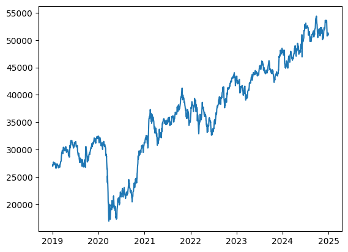

```python
plt.plot(df['Close'])
```

```python
df.describe( ).T
```

| Price | Ticker | count | mean | std | min | 25% | 50% | 75% | max |
| --- | --- | --- | --- | --- | --- | --- | --- | --- | --- |
| Close | ^NSEBANK | 1472.0 | 3.674547e+04 | 8.885136e+03 | 16917.453125 | 30452.458496 | 36155.128906 | 43853.087891 | 5.437535e+04 |
| High | ^NSEBANK | 1472.0 | 3.703347e+04 | 8.874943e+03 | 17681.493283 | 30698.755586 | 36498.802300 | 44030.150391 | 5.446735e+04 |
| Low | ^NSEBANK | 1472.0 | 3.645257e+04 | 8.893199e+03 | 16116.062322 | 30238.197732 | 35838.208973 | 43645.688477 | 5.401090e+04 |
| Open | ^NSEBANK | 1472.0 | 3.676839e+04 | 8.878321e+03 | 16759.754383 | 30532.857845 | 36203.678629 | 43857.363281 | 5.433870e+04 |
| Volume | ^NSEBANK | 1472.0 | 1.644332e+06 | 4.740937e+07 | 0.000000 | 0.000000 | 160350.000000 | 241650.000000 | 1.798102e+09 |

```python
# Check for missing values
df.isnull().sum()
```

```
Price   Ticker
Close   ^NSEBANK    0
High    ^NSEBANK    0
Low     ^NSEBANK    0
Open    ^NSEBANK    0
Volume  ^NSEBANK    0
dtype: int64
```

```python
df.shape
```

```
(1472, 5)
```

```python
import numpy as np
df['open-close']  = df['Open'] - df['Close']
df['low-high']  = df['Low'] - df['High']
df['target'] = np.where(df['Close'].shift(-1) > df['Close'], 1, 0)
```

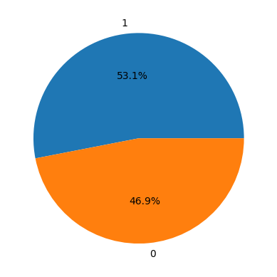

```python
plt.pie(df['target'].value_counts().values,
        labels=[1, 0], autopct='%1.1f%%')
plt.show()
```

```python
# generate features & labels
def generate_xy(frame):
    df = frame.copy()
    df['Returns'] = dailyReturn(df['Close'])

    # Create features (predictors) list
    features_list = []
    for r in range(10, 65, 5):
        df['Ret_'+str(r)] = df.Returns.rolling(r).sum()
        df['Std_'+str(r)] = df.Returns.rolling(r).std()
        features_list.append('Ret_'+str(r))
        features_list.append('Std_'+str(r))

    # Define Target
    df['Label'] = np.where(lead(df['Close']) > 0.995 * df['Close'], 1, 0)

    # Drop NaN values
    return df.dropna()
```

```python
# extract features
data = generate_xy(df)
X = data.drop(columns=['Open', 'High', 'Low', 'Close', 'Volume', 'Returns', 'Label'])
X
```

| Price Ticker Date | open-close | low-high | target | Ret_10 | Std_10 | Ret_15 | Std_15 | Ret_20 | Std_20 | Ret_25 | ... | Ret_40 | Std_40 | Ret_45 | Std_45 | Ret_50 | Std_50 | Ret_55 | Std_55 | Ret_60 | Std_60 |
| --- | --- | --- | --- | --- | --- | --- | --- | --- | --- | --- | --- | --- | --- | --- | --- | --- | --- | --- | --- | --- | --- |
| 2019-04-02 | 95.848493 | -297.047322 | 0 | 0.032573 | 0.009313 | 0.089275 | 0.009184 | 0.124912 | 0.008591 | 0.115161 | ... | 0.123584 | 0.008371 | 0.107855 | 0.008636 | 0.099343 | 0.008372 | 0.090768 | 0.008204 | 0.110650 | 0.008077 |
| 2019-04-03 | 347.544790 | -566.294202 | 0 | 0.016660 | 0.009891 | 0.073290 | 0.009909 | 0.106841 | 0.009168 | 0.113383 | ... | 0.097583 | 0.008243 | 0.098647 | 0.008788 | 0.089072 | 0.008506 | 0.089079 | 0.008240 | 0.109954 | 0.008092 |
| 2019-04-04 | 242.397573 | -435.793762 | 1 | 0.004593 | 0.010067 | 0.050096 | 0.009705 | 0.081873 | 0.008953 | 0.096305 | ... | 0.099007 | 0.008201 | 0.097924 | 0.008803 | 0.085412 | 0.008560 | 0.085514 | 0.008289 | 0.094989 | 0.008108 |
| 2019-04-05 | -81.799831 | -323.996235 | 0 | 0.008427 | 0.010211 | 0.040717 | 0.009162 | 0.085270 | 0.008955 | 0.109922 | ... | 0.101291 | 0.008217 | 0.121111 | 0.008308 | 0.088608 | 0.008581 | 0.099026 | 0.008215 | 0.096962 | 0.008122 |
| 2019-04-08 | 356.195070 | -515.445168 | 1 | 0.008844 | 0.010170 | 0.031387 | 0.009569 | 0.072266 | 0.009360 | 0.107652 | ... | 0.090178 | 0.008383 | 0.116117 | 0.008418 | 0.082487 | 0.008677 | 0.085457 | 0.008302 | 0.081496 | 0.008178 |
| ... | ... | ... | ... | ... | ... | ... | ... | ... | ... | ... | ... | ... | ... | ... | ... | ... | ... | ... | ... | ... | ... |
| 2024-12-23 | -273.203125 | -386.953125 | 0 | -0.039922 | 0.009344 | -0.015304 | 0.009326 | -0.017192 | 0.008239 | 0.022426 | ... | -0.004153 | 0.010298 | 0.000561 | 0.010230 | -0.004148 | 0.010016 | -0.010229 | 0.010147 | -0.052831 | 0.010352 |
| 2024-12-24 | 81.949219 | -244.601562 | 0 | -0.044749 | 0.009053 | -0.028151 | 0.008692 | -0.018536 | 0.008240 | 0.017111 | ... | 0.008735 | 0.010033 | -0.016670 | 0.009953 | 0.001185 | 0.009970 | -0.004461 | 0.010101 | -0.059527 | 0.010323 |
| 2024-12-26 | 225.101562 | -788.199219 | 1 | -0.042482 | 0.009109 | -0.040148 | 0.007966 | -0.021864 | 0.008209 | 0.010692 | ... | -0.001730 | 0.009928 | -0.015359 | 0.009949 | -0.012549 | 0.009806 | 0.013612 | 0.009752 | -0.050744 | 0.010255 |
| 2024-12-27 | -43.101562 | -388.347656 | 0 | -0.036457 | 0.009375 | -0.043704 | 0.007729 | -0.011540 | 0.008103 | 0.018458 | ... | -0.019481 | 0.009367 | 0.001056 | 0.009748 | -0.011523 | 0.009812 | 0.005674 | 0.009653 | -0.031968 | 0.010068 |
| 2024-12-30 | 302.601562 | -1261.398438 | 0 | -0.050348 | 0.008643 | -0.048960 | 0.007792 | -0.021414 | 0.008183 | -0.003578 | ... | -0.016636 | 0.009305 | -0.005602 | 0.009804 | -0.016512 | 0.009855 | -0.001064 | 0.009701 | -0.037932 | 0.010103 |

1412 rows × 25 columns

Target or Label Definition

Label or the target variable is also known as the dependent variable. Here, the target variable is whether the underlying price will close up or down on the next trading day. If the tomorrow’s closing price is greater than 99.50% of today’s closing price, then we will buy the underlying, else do nothing.

We assign a value of +1 for the buy signal and 0 otherwise to target variable. The target can be described as :

$$ y_t = \begin{cases} +1, & \text{if } p_{t+1} > 0.995 ^* p_t, \\ 0, & \text{otherwise.} \end{cases} $$

where,p_t is the current closing price of the underlying and p_t+1 is the 1-day forward closing price of the underlying.

```python
import pandas as pd
# get labels
y = data['Label']

# check class imbalance
pd.Series(y).value_counts()
```

```
Label
1    999
0    413
Name: count, dtype: int64
```

```python
pip install --upgrade xgboost
```

```python
from xgboost import XGBClassifier

from sklearn.model_selection import train_test_split

# Assuming 'X' and 'y' are your features and target variable
X_train, X_test, y_train, y_test = train_test_split(X, y, test_size=0.2, shuffle=False) # Split data with shuffle=False for time series

# Now you can proceed with fitting the model
basemodel = XGBClassifier(use_label_encoder=False, random_state=28)
basemodel.fit(X_train, y_train)

# Then make predictions as usual
y_pred = basemodel.predict(X_test)
y_proba = basemodel.predict_proba(X_test)

import warnings
warnings.filterwarnings("ignore", category=FutureWarning)
```

```python
# accuracy of the model
acc_train = accuracy_score(y_train, basemodel.predict(X_train))
acc_test = accuracy_score(y_test, y_pred)

print(f'Train Accuracy: {acc_train:0.4}, Test Accuracy: {acc_test:0.4}')
```

```
Train Accuracy: 1.0, Test Accuracy: 0.7668
```

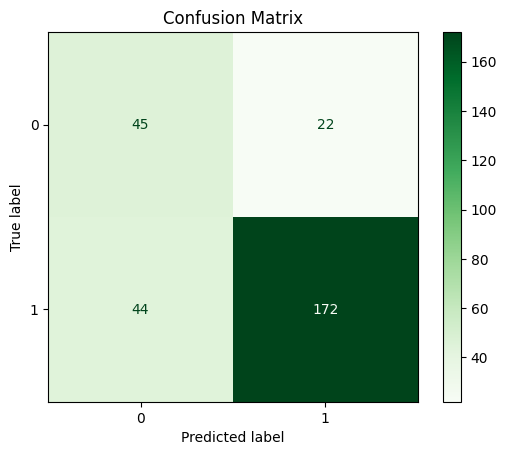

```python
from sklearn.metrics import ConfusionMatrixDisplay, confusion_matrix
import matplotlib.pyplot as plt

# Generate predictions
y_pred = basemodel.predict(X_test)

# Compute and display confusion matrix
cm = confusion_matrix(y_test, y_pred)
disp = ConfusionMatrixDisplay(confusion_matrix=cm, display_labels=basemodel.classes_)
disp.plot(cmap=plt.cm.Greens)

plt.title('Confusion Matrix')
plt.show()
```

```python
# Classification Report
print(classification_report(y_test, y_pred))
```

```
              precision    recall  f1-score   support

           0       0.51      0.67      0.58        67
           1       0.89      0.80      0.84       216

    accuracy                           0.77       283
   macro avg       0.70      0.73      0.71       283
weighted avg       0.80      0.77      0.78       283
```

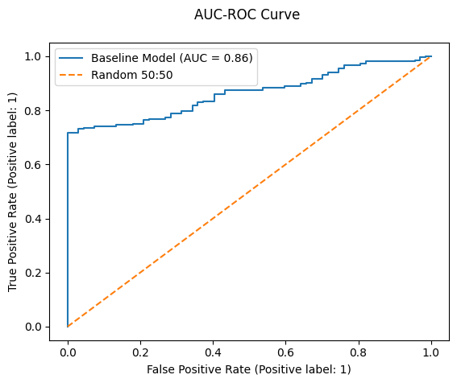

```python
from sklearn.metrics import RocCurveDisplay, roc_auc_score
import matplotlib.pyplot as plt

# Generate predicted probabilities for the positive class
y_proba = basemodel.predict_proba(X_test)[:, 1]  # Probabilities for the positive class

# Display the ROC curve
disp = RocCurveDisplay.from_predictions(
    y_test,
    y_proba,
    name='Baseline Model'
)
plt.plot([0,1], [0,1], linestyle="--", label='Random 50:50')  # Diagonal line
plt.title("AUC-ROC Curve \n")
plt.legend()
plt.show()
```

```python
# Cross-validation
tscv = TimeSeriesSplit(n_splits=5, gap=1)
```

```python
# Get parameters list
basemodel.get_params()
```

```
{'objective': 'binary:logistic',
 'base_score': None,
 'booster': None,
 'callbacks': None,
 'colsample_bylevel': None,
 'colsample_bynode': None,
 'colsample_bytree': None,
 'device': None,
 'early_stopping_rounds': None,
 'enable_categorical': False,
 'eval_metric': None,
 'feature_types': None,
 'gamma': None,
 'grow_policy': None,
 'importance_type': None,
 'interaction_constraints': None,
 'learning_rate': None,
 'max_bin': None,
 'max_cat_threshold': None,
 'max_cat_to_onehot': None,
 'max_delta_step': None,
 'max_depth': None,
 'max_leaves': None,
 'min_child_weight': None,
 'missing': nan,
 'monotone_constraints': None,
 'multi_strategy': None,
 'n_estimators': None,
 'n_jobs': None,
 'num_parallel_tree': None,
 'random_state': 28,
 'reg_alpha': None,
 'reg_lambda': None,
 'sampling_method': None,
 'scale_pos_weight': None,
 'subsample': None,
 'tree_method': None,
 'validate_parameters': None,
 'verbosity': None,
 'use_label_encoder': False}
```

```python
!pip install scikit-optimize
```

```python
from skopt import BayesSearchCV
from sklearn.ensemble import RandomForestClassifier
from sklearn.model_selection import train_test_split, TimeSeriesSplit
from sklearn.datasets import make_classification

# Generate data
X, y = make_classification(n_samples=1000, n_features=10, random_state=42)
X_train, X_test, y_train, y_test = train_test_split(X, y, test_size=0.2, random_state=42)

# Extended search space
search_space = {
    'n_estimators': (100, 500),
    'max_depth': (5, 50),
    'min_samples_split': (2, 10),
    'min_samples_leaf': (1, 8),
    'max_features': (1, 'sqrt', 'log2'),
    'bootstrap': [True, False]
}

# TimeSeriesSplit for financial data
tscv = TimeSeriesSplit(n_splits=5)

# Model and BayesSearchCV
model = RandomForestClassifier(random_state=42)
bayes_search = BayesSearchCV(
    estimator=model,
    search_spaces=search_space,
    n_iter=30,
    cv=tscv,
    scoring='accuracy',  # Replace with a custom metric if needed
    random_state=42,
    n_jobs=-1
)

# Fit the model
bayes_search.fit(X_train, y_train)

# Results
print("Best parameters:", bayes_search.best_params_)
print("Best accuracy:", bayes_search.best_score_)
```

```
Best parameters: OrderedDict({'bootstrap': False, 'max_depth': 41, 'max_features': 'sqrt', 'min_samples_leaf': 1, 'min_samples_split': 7, 'n_estimators': 500})
Best accuracy: 0.8977443609022556
```

```python
# predict using the best model
tunedmodel = bayes_search.best_estimator_

# Predict class labels
y_pred = tunedmodel.predict(X_test)

# Predict Probabilities
# y_proba = tunedmodel.predict_proba(X_test)[:,1]

# Measure Accuracy
acc_train = accuracy_score(y_train, tunedmodel.predict(X_train))
acc_test = accuracy_score(y_test, y_pred)

# Print Accuracy
print(f'\n Training Accuracy \t: {acc_train :0.4} \n Test Accuracy \t\t: {acc_test :0.4}')
```

```
 Training Accuracy 	: 1.0
 Test Accuracy 		: 0.885
```

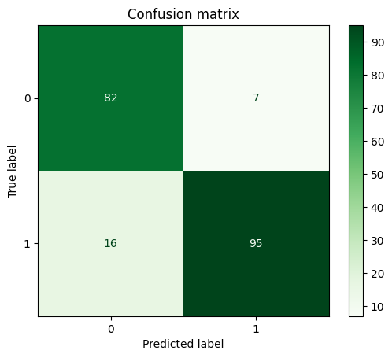

```python
# Display confussion matrix
disp = ConfusionMatrixDisplay.from_estimator(
        tunedmodel,
        X_test,
        y_test,
        # display_labels=tunedmodel.classes_,
        cmap=plt.cm.Greens
    )
plt.title('Confusion matrix')
plt.show()
```

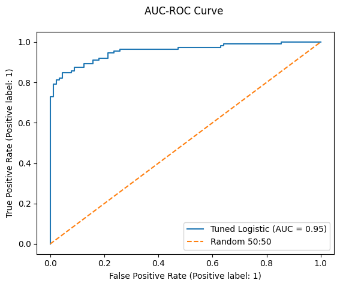

```python
# Display ROCCurve
disp = RocCurveDisplay.from_estimator(
            tunedmodel,
            X_test,
            y_test,
            name='Tuned Logistic')
plt.title("AUC-ROC Curve \n")
plt.plot([0,1],[0,1],linestyle="--", label='Random 50:50')
plt.legend()
plt.show()
```

```python
# Classification Report
print(classification_report(y_test, y_pred))
```

```
              precision    recall  f1-score   support

           0       0.84      0.92      0.88        89
           1       0.93      0.86      0.89       111

    accuracy                           0.89       200
   macro avg       0.88      0.89      0.88       200
weighted avg       0.89      0.89      0.89       200
```

**Feature Importance**

Feature Importance refers to techniques that calculate a score for all the input features for a given model where the scores represent the “importance” of each feature. It is calculated as the decrease in node impurity weighted by the probability of reaching that node. The node probability can be calculated by the number of samples that reach the node, divided by the total number of samples. The higher the value the more important the feature.

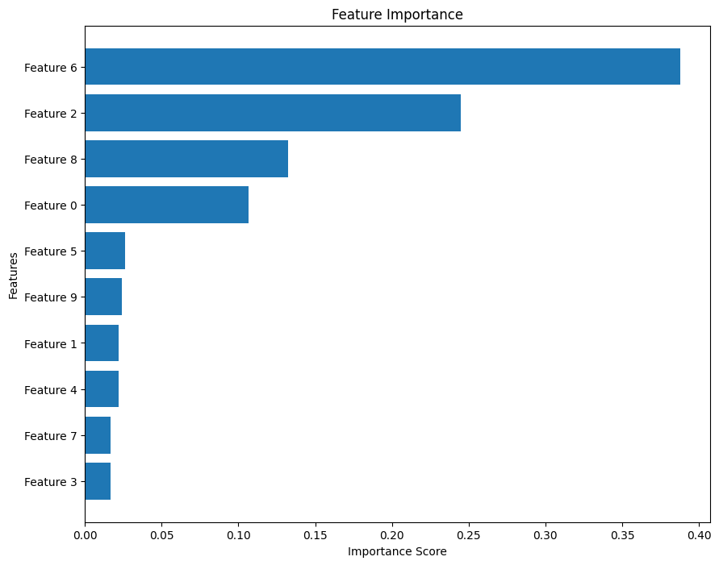

```python
import matplotlib.pyplot as plt
import pandas as pd

# Ensure feature names are defined
feature_names = [f"Feature {i}" for i in range(X.shape[1])]

# Create a DataFrame for feature importance
feature_imp = pd.DataFrame({
    'Importance Score': tunedmodel.feature_importances_,
    'Features': feature_names
}).sort_values(by='Importance Score', ascending=False)

# Plot feature importance
fig, ax = plt.subplots(figsize=(10, 8))
plt.barh(feature_imp['Features'], feature_imp['Importance Score'])
plt.xlabel('Importance Score')
plt.ylabel('Features')
plt.title('Feature Importance')
plt.gca().invert_yaxis()
plt.show()
```

**Shap** **Values**

SHAP (SHapley Additive exPlanations) is a game theoretic approach to explain the output of any machine learning model. Shapley values are a widely used approach from cooperative game theory that come with desirable properties and is the average marginal contribution of a feature value across all possible coalitions.

```python
# Shap explainer
explainer = shap.TreeExplainer(tunedmodel)
shap_values = explainer.shap_values(X_test)
```

[figure not shown]

```python
# future importance summary
shap.summary_plot(shap_values, X_test, plot_type="bar")
```

**Trading Strategy**

Let's now define a trading strategy. We will use the predicted signal to buy or sell. We then compare the result of this strategy with the buy and hold and visualize the performance of the Algorithm.

```python
# Subsume into a new dataframe
df1 = df[-len(X_test):].copy()                                  # df[-len(X_test):]
df1['Signal'] = tunedmodel.predict(X_test)                      # tunedmodel.predict(X_test)
```

```python
# Daily Returns - Benchmark return
df1['Returns'] = np.log(df1['Close']).diff().fillna(0)

# Strategy Returns - Logistic
df1['Strategy'] =  df1['Returns'] * df1['Signal'].shift(1).fillna(0)

df1
```

| Price Ticker Date | Close ^NSEBANK | High ^NSEBANK | Low ^NSEBANK | Open ^NSEBANK | Volume ^NSEBANK | open-close | low-high | target | Signal | Returns | Strategy |
| --- | --- | --- | --- | --- | --- | --- | --- | --- | --- | --- | --- |
| 2024-03-06 | 47965.398438 | 48161.250000 | 47442.250000 | 47451.648438 | 301700 | -513.750000 | -719.000000 | 0 | 0 | 0.000000 | 0.000000 |
| 2024-03-07 | 47835.800781 | 48071.699219 | 47747.199219 | 48035.800781 | 146300 | 200.000000 | -324.500000 | 0 | 1 | -0.002706 | -0.000000 |
| 2024-03-11 | 47327.851562 | 47853.800781 | 47230.648438 | 47792.199219 | 204200 | 464.347656 | -623.152344 | 0 | 0 | -0.010675 | -0.010675 |
| 2024-03-12 | 47282.398438 | 47812.750000 | 46884.449219 | 47351.351562 | 207200 | 68.953125 | -928.300781 | 0 | 1 | -0.000961 | -0.000000 |
| 2024-03-13 | 46981.300781 | 47468.699219 | 46842.148438 | 47341.148438 | 274600 | 359.847656 | -626.550781 | 0 | 0 | -0.006388 | -0.006388 |
| ... | ... | ... | ... | ... | ... | ... | ... | ... | ... | ... | ... |
| 2024-12-23 | 51317.601562 | 51417.351562 | 51030.398438 | 51044.398438 | 110800 | -273.203125 | -386.953125 | 0 | 0 | 0.010941 | 0.010941 |
| 2024-12-24 | 51233.000000 | 51382.101562 | 51137.500000 | 51314.949219 | 112000 | 81.949219 | -244.601562 | 0 | 0 | -0.001650 | -0.000000 |
| 2024-12-26 | 51170.699219 | 51740.000000 | 50951.800781 | 51395.800781 | 100 | 225.101562 | -788.199219 | 1 | 1 | -0.001217 | -0.000000 |
| 2024-12-27 | 51311.300781 | 51628.449219 | 51240.101562 | 51268.199219 | 78200 | -43.101562 | -388.347656 | 0 | 1 | 0.002744 | 0.002744 |
| 2024-12-30 | 50952.750000 | 51979.750000 | 50718.351562 | 51255.351562 | 316300 | 302.601562 | -1261.398438 | 0 | 1 | -0.007012 | -0.007012 |

200 rows × 11 columns

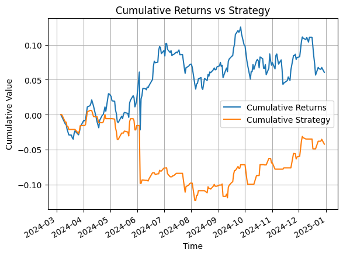

```python
import matplotlib.pyplot as plt

# Plot cumulative returns and strategy
df1.Returns.cumsum().plot(label='Cumulative Returns')
df1.Strategy.cumsum().plot(label='Cumulative Strategy')

# Add labels, title, and legend
plt.xlabel('Time')
plt.ylabel('Cumulative Value')
plt.title('Cumulative Returns vs Strategy')
plt.legend()  # Display the legend
plt.grid(True)  # Optional: Add a grid for better readability
plt.show()
```

```python
# Ensure both columns exist
if 'Returns' in df1.columns and 'Strategy' in df1.columns:
    # Display both columns
    combined_df = df1[['Returns', 'Strategy']]
    print(combined_df.tail())
else:
    print("Columns 'Returns' or 'Strategy' are missing. Check df1.columns.")
```

```
Price        Returns  Strategy
Ticker
Date
2024-12-23  0.010941  0.010941
2024-12-24 -0.001650 -0.000000
2024-12-26 -0.001217 -0.000000
2024-12-27  0.002744  0.002744
2024-12-30 -0.007012 -0.007012
```

```python
# Display descriptive statistics for Returns and Strategy
stats = df1[['Returns', 'Strategy']].describe()
print(stats)
```

```
Price      Returns    Strategy
Ticker
count   200.000000  200.000000
mean      0.000302   -0.000212
std       0.011131    0.008104
min      -0.082805   -0.082805
25%      -0.005219    0.000000
50%       0.000482    0.000000
75%       0.005288    0.001141
max       0.044307    0.020749
```

```python
# Calculate correlation
correlation = df1[['Returns', 'Strategy']].corr()
print("Correlation between Returns and Strategy:")
print(correlation)
```

```
Correlation between Returns and Strategy:
Price             Returns  Strategy
Ticker
Price    Ticker
Returns          1.000000  0.729251
Strategy         0.729251  1.000000
```

```python
import numpy as np
import scipy.stats as stats

# Calculate Sharpe Ratio
risk_free_rate = 0.0625 / 252  # Assuming 6% annualized and 252 trading days
sharpe_strategy = (df1['Strategy'].mean() - risk_free_rate) / df1['Strategy'].std()
sharpe_returns = (df1['Returns'].mean() - risk_free_rate) / df1['Returns'].std()

print(f"Sharpe Ratio - Strategy: {sharpe_strategy:.2f}, Returns: {sharpe_returns:.2f}")

# Skewness and Kurtosis
skew_strategy = stats.skew(df1['Strategy'])
skew_returns = stats.skew(df1['Returns'])
kurt_strategy = stats.kurtosis(df1['Strategy'])
kurt_returns = stats.kurtosis(df1['Returns'])

print(f"Skewness - Strategy: {skew_strategy:.2f}, Returns: {skew_returns:.2f}")
print(f"Kurtosis - Strategy: {kurt_strategy:.2f}, Returns: {kurt_returns:.2f}")
```

```
Sharpe Ratio - Strategy: -0.06, Returns: 0.00
Skewness - Strategy: -5.37, Returns: -1.57
Kurtosis - Strategy: 53.17, Returns: 15.89
```